# Regression Models Course Project

John B Cheadle

October 17, 2017

# Executive Summary

This report explores the relationship between between a set of variables and miles per gallon (MPG) using the mtcars data set. Specifically, the repot seeks to answer two questions:

1. Is an automatic or manual transmission better for MPG?
2. What is the quantifiable difference between automatic and manual transmissions?

# Exploring the mtcars data set

To start, we look at some aspects of the mtcars data set.

```
## starting httpd help server ...
```

```
##  done
```

```
##                    mpg cyl disp  hp drat    wt  qsec vs am gear carb
## Mazda RX4         21.0   6  160 110 3.90 2.620 16.46  0  1    4    4
## Mazda RX4 Wag     21.0   6  160 110 3.90 2.875 17.02  0  1    4    4
## Datsun 710        22.8   4  108  93 3.85 2.320 18.61  1  1    4    1
## Hornet 4 Drive    21.4   6  258 110 3.08 3.215 19.44  1  0    3    1
## Hornet Sportabout 18.7   8  360 175 3.15 3.440 17.02  0  0    3    2
## Valiant           18.1   6  225 105 2.76 3.460 20.22  1  0    3    1
```

```
##       mpg       cyl      disp        hp      drat        wt      qsec
## "numeric" "numeric" "numeric" "numeric" "numeric" "numeric" "numeric"
##        vs        am      gear      carb
## "numeric" "numeric" "numeric" "numeric"
```

Here we get a sense of the mtcars data set. We learn that ‘am’ is one of the main variables we want to regress on (0 = automatic, 1 = manual).

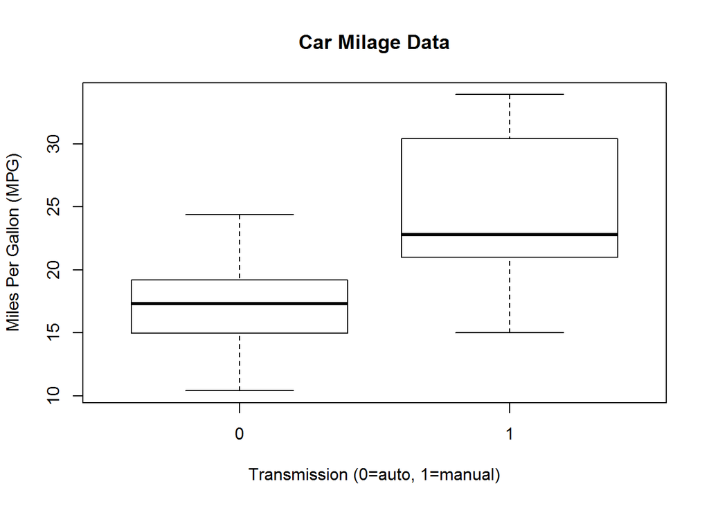

It appears from the relative means of MPG for automatic and manaul transmission that these two variables are correlated. In the following sections, we fit a linear model using lm() with the outcome ‘mpg’ and the primary regressor ‘am’ from the mtcars data set.

# Model Fitting

The initial model fitted used the variable am as the regressor to the mpg outcome.

```r
fit1 <- lm(mpg ~ factor(am), data=mtcars)
summary(fit1)$coef
```

```
##              Estimate Std. Error   t value     Pr(>|t|)
## (Intercept) 17.147368   1.124603 15.247492 1.133983e-15
## factor(am)1  7.244939   1.764422  4.106127 2.850207e-04
```